# Final exam

Q1. From the dataset `heights` in the `dslabs` package, please describe the distribution of male and female heights. If you pick a female at random, what is the probability that she is 61 inches or shorter?

```r
#load data
library(dslabs)
library(tidyverse)
data(heights)
m <- filter(heights, sex == 'Male')
f <- filter(heights, sex == 'Female')
```

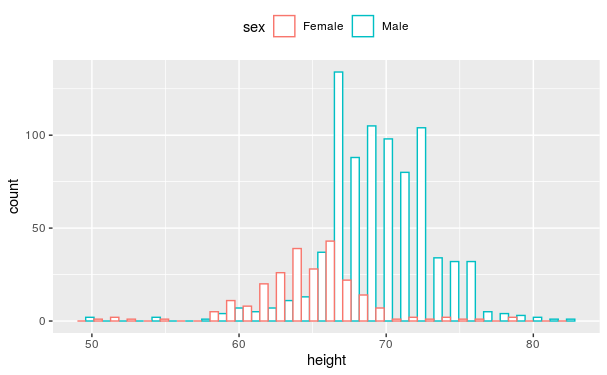

```r
#see the distribution

ggplot(heights, aes(x=height, color=sex)) +
  geom_histogram(fill="white", position="dodge")+
  theme(legend.position="top")
```

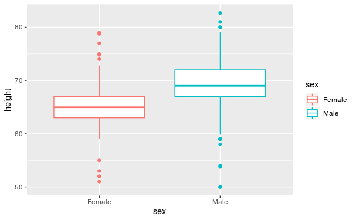

```r
ggplot(heights, aes(x = sex, y = height)) +
  geom_boxplot(aes(color = sex))
```

```r
mean(m$height)
```

```
[1] 69.31475
```

```r
sd(m$height)
```

```
[1] 3.611024
```

```r
mean(f$height)
```

```
[1] 64.93942
```

```r
sd(f$height)
```

```
[1] 3.760656
```

From the plot, we can describe the distribution as:

1. There are more data of the male than the that of the female in data `heights`.
2. According to the data, males are usually taller than females.
3. The standard deviation of females’ data is slightly bigger that the males’.

```r
#pick a female by random

f_s <- sample(f$height, 1)
mean(f$height <= 61)
```

```
[1] 0.1218487
```

Q2. For American Roulette, there are 19 reds, 16 blacks and 3 greens. The payout for winning on green is 15 dollars. You create a random variable that is the sum of your winnings after betting on green 1000 times. Start your code by setting the seed to 1. Describe your random variable (e.g. the expected value, the standard error). Then, create a Monte Carlo simulation that generates 1,000 outcomes of a random variable, and then describe your result.

```r
#create a random variable
N <- 1000

set.seed(1)
dollars <- function(n){
  x <- sample(c(15,-1), n, replace = TRUE, prob = c(3/38,35/38))
  sum(x)
}

dollars(N)
```

```
[1] 472
```

```r
#expected value
15*(3/38) - 35/38
```

```
[1] 0.2631579
```

```r
#standard error
sqrt(N)*16*sqrt(3/38*35/38)
```

```
[1] 136.4366
```

```r
#create a Monte Carlo simulation
N <- 1000
B <- 1000

set.seed(1)
dollars <- function(n){
  x <- sample(c(15,-1), n, replace = TRUE, prob = c(3/38,35/38))
  sum(x)
}

S <- replicate(B, dollars(N))

#expected value of Monte Carlo simulation
mean(S)
```

```
[1] 257.024
```

```r
#se of Monte Carlo simulation
sd(S)
```

```
[1] 138.0665
```

Q3. From the poll example, we will create a Monte Carlo simulation for p = 0.45. You will compare the sampling size(N) for 10, 1000, and the repeat size(B) for 100, 10000. So you should have four combinations (10N x 100B, 1000N x 100B, 10N x 10000B, 1000N x 10000B). Please describe your Monte Carlo simulation results, and compare four combinations.

```r
#create a Monte Carlo simulation
p <- 0.45

set.seed(1)
Mon <- function(n){
  x <- sample(c(1,-1), n, replace = TRUE, prob = c(p,1-p))
  sum(x)
}

m1 <- replicate(100, Mon(10))
m2 <- replicate(100, Mon(1000))
m3 <- replicate(10000, Mon(10))
m4 <- replicate(10000, Mon(1000))

library(plyr)
M1 <- as.data.frame(m1) %>% mutate(n = seq(1,nrow(M1)))
M2 <- as.data.frame(m2) %>% mutate(n = seq(1,nrow(M2)))
M3 <- as.data.frame(m3) %>% mutate(n = seq(1,nrow(M3)))
M4 <- as.data.frame(m4) %>% mutate(n = seq(1,nrow(M4)))
```

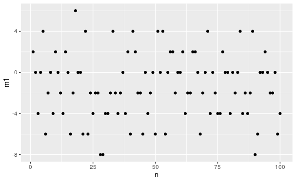

```r
M1 %>% ggplot(aes(m1, n))+
  geom_point()+
  coord_flip()
```

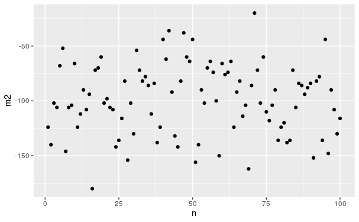

```r
M2 %>% ggplot(aes(m2, n))+
  geom_point()+
  coord_flip()
```

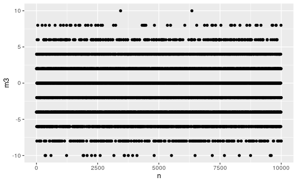

```r
M3 %>% ggplot(aes(m3, n))+
  geom_point()+
  coord_flip()
```

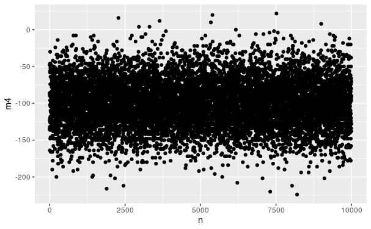

```r
M4 %>% ggplot(aes(m4, n))+
  geom_point()+
  coord_flip()
```

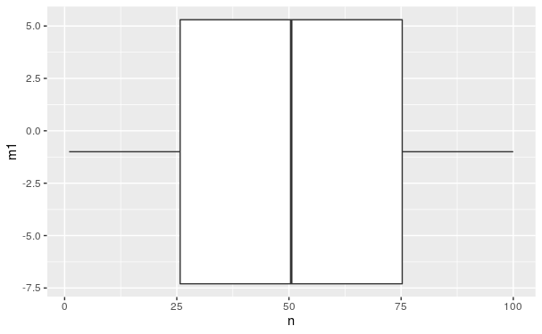

```r
M1 %>% ggplot(aes(m1, n))+
  geom_boxplot()+
  coord_flip()
```

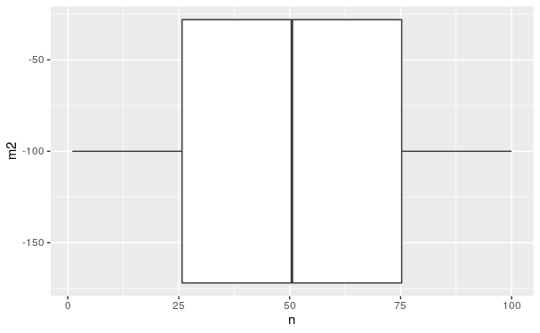

```r
M2 %>% ggplot(aes(m2, n))+
  geom_boxplot()+
  coord_flip()
```

```r
M3 %>% ggplot(aes(m3, n))+
 geom_boxplot()+
  coord_flip()
M4 %>% ggplot(aes(m4, n))+
  geom_boxplot()+
  coord_flip()
```

[output not shown]

```r
mean(M1$m1)
```

```
[1] -1.36
```

```r
sd(M1$m1)
```

```
[1] 3.163938
```

```r
mean(M2$m2)
```

```
[1] -98.44
```

```r
sd(M2$m2)
```

```
[1] 32.0348
```

```r
mean(M3$m3)
```

```
[1] -0.9824
```

```r
sd(M3$m3)
```

```
[1] 3.117926
```

```r
mean(M4$m4)
```

```
[1] -99.8786
```

```r
sd(M4$m4)
```

```
[1] 31.55394
```

The mean and the se are tend to depend on the size of N.